# Ayudantía II: Introducción al análisis con `R`

# **Ejercicio III: Gráficos Descriptivos en `R`**

## Histogramas

**14.a Compare las distribuciones de los puntajes de lenguaje, matemáticas y ciencia**

- Histograma para variables numéricas

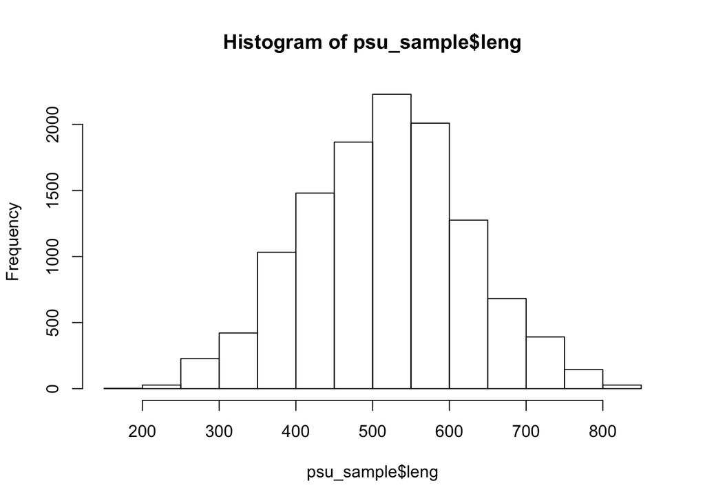

```r
#Para variable numerica.
hist(psu_sample$leng)
```

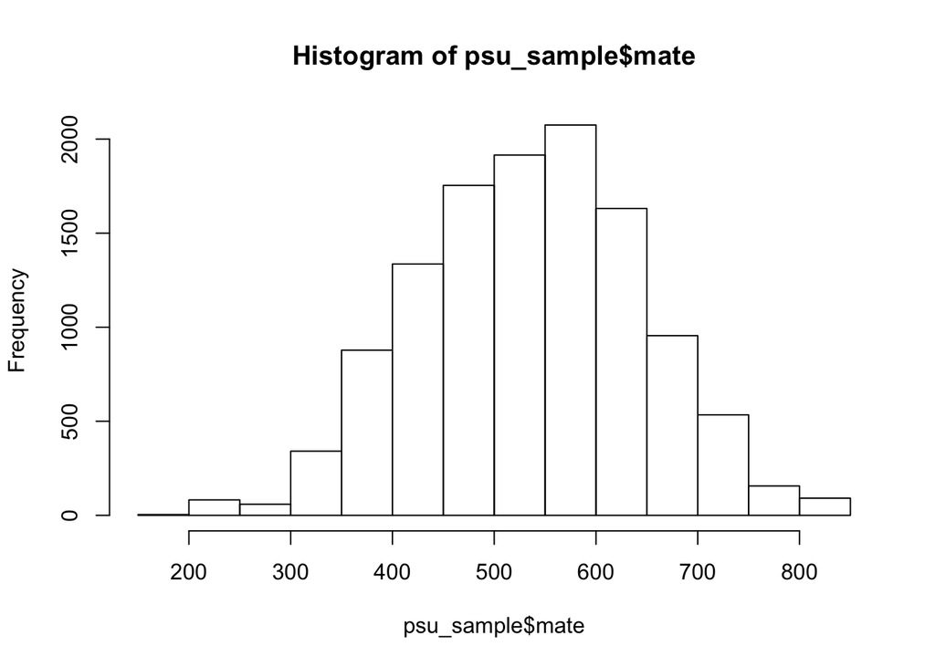

```r
hist(psu_sample$mate)
```

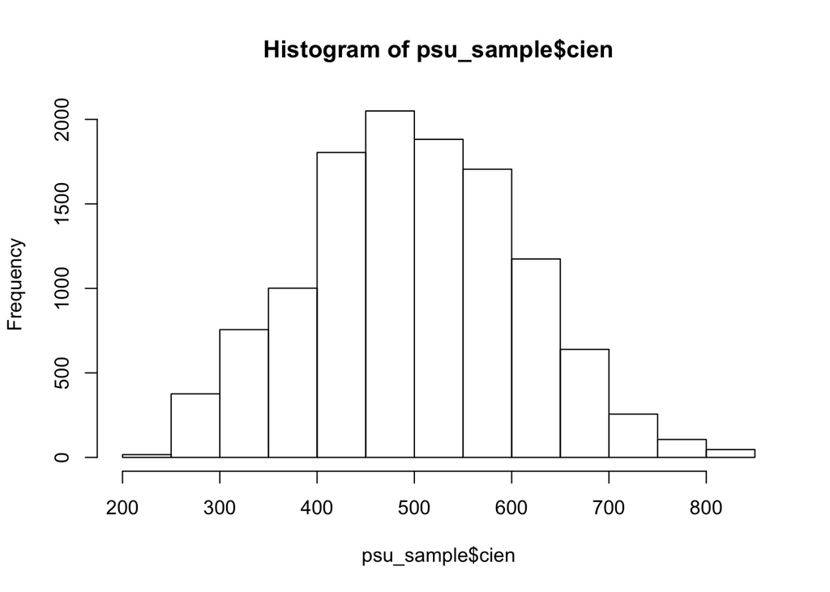

```r
hist(psu_sample$cien)
```

**14.b. Revise los outliers en las pruebas de lenguaje, matemáticas y ciencia**

## Boxplots

- Boxplots de variables

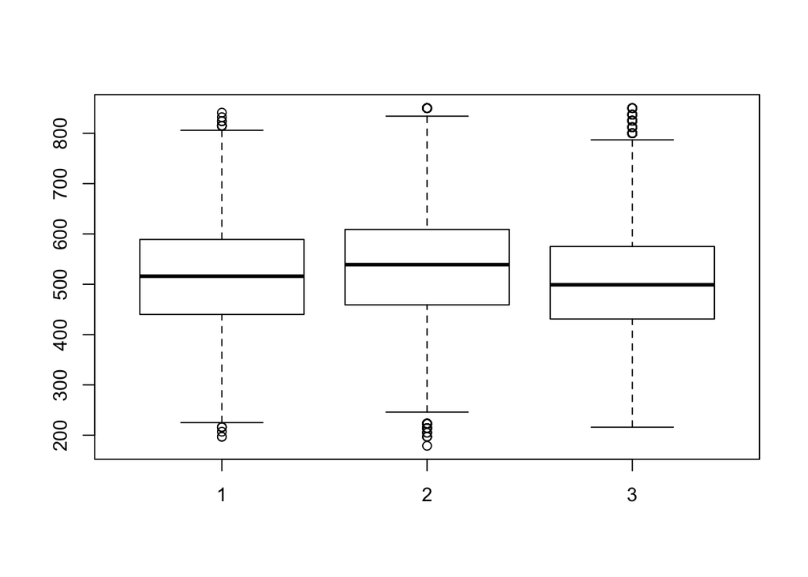

```r
boxplot(psu_sample$leng, psu_sample$mate, psu_sample$cien)
```

**14.c. Revise la dispersión de puntajes lenguaje comparando entre mujeres y hombres**

- Boxplot comparativo entre categorías de variables

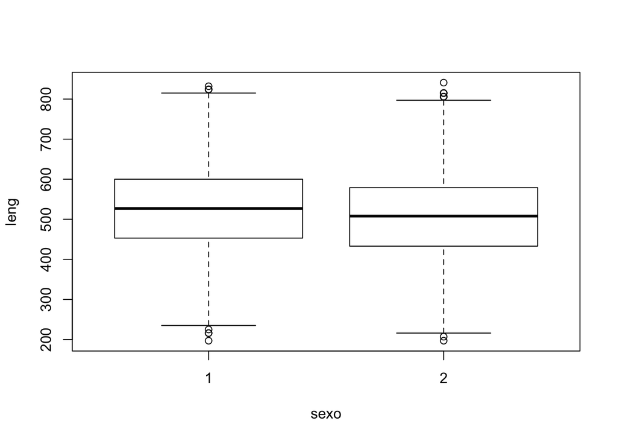

```r
boxplot(leng ~ sexo, data=psu_sample)
```

# **Resumen de funciones**

## Comandos de `SPSS` a `R`

[output not shown]

## Operadores lógicos en `R`

| Operadores lógicos | Significado | Operadores lógicos | Significado |
| --- | --- | --- | --- |
| `&` | y | `>=` | Mayor o igual que |
| `\|` | O | `<=` | Menor o igual que |
| `!` | No | `==` | Igual |
| `~` | No | `!= o ~=` | No igual |
| `>` | Mayor que | `NA` | Valores perdidos* |
| `<` | Menor que | `is.na(data$var)` | Valores perdidos |

## Tipos de variables

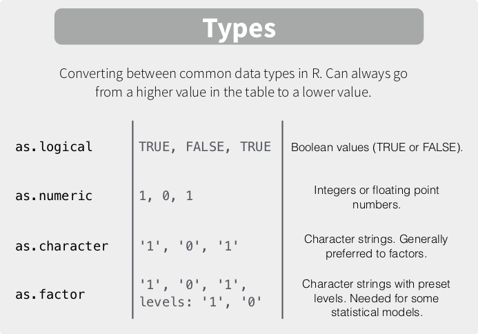

# **Referencias**

## Libro base de contenidos

[Wooldridge, Jeffrey M. (2009). Introducción a la econometría: un enfoque moderno. 4a edición. Mé́xico: Cengage Learning.](https://www.dropbox.com/sh/t0s4r6yuzgcwt10/AAB9DxspiUmAqihGAITmhQpca?dl=0)

- Caps A.2, B.3, y 2.1.

[figure not shown]

## Libro base del curso para el uso R

[Fox, John y Sanford Weisberg (2019). An R Companion to Applied Regression. Third Edition. SAGE.](https://www.dropbox.com/sh/t0s4r6yuzgcwt10/AAB9DxspiUmAqihGAITmhQpca?dl=0)

- Caps 1 y 2.

[figure not shown]

## Referencias para visualización de datos

- [Capítulo 4 Visualización de Datos](https://arcruz0.github.io/libroadp/dataviz.html)
- [R for data science](https://r4ds.had.co.nz/data-visualisation.html)
- [Capítulo 8 Construcción de gráficos usando RStudio: funcionalidades básicas y uso del paquete ggplot2](https://bookdown.org/gboccardo/manual-ED-UCH/construccion-de-graficos-usando-rstudio-funcionalidades-basicas-y-uso-del-paquete-ggplot2.html#histogramas)

## Ayudantías

Puedes encontrar las carpetas con las ayudantías en pdf y bases de datos en el siguiente [Link](https://github.com/JDConejeros/SOL201S_Datos_3)

La próxima ayudantía veremos:

- Regresión simple
- Ejercicios de regresión simple